# A5/6 catches relative to preseason coho FRAM cohort

D Auerbach, A Hagen-Breaux

2022-03-10

This analysis addresses the question of whether preseason forecast cohorts $cohort_{pre}$ (i.e., returning run sizes) are an effective predictor of estimated actual catches $catch_{post}$. That is, does $catch_{post} \sim cohort_{pre}$ hold? The catches are the quantity of interest, the forecast is the quantity that is available. If a relationship exists between post-season estimates of catches or encounters and post-season estimates of returning cohorts, then the utility of that relationship in the preseason depends on how well the preseason cohort forecasts capture the post-season mortality estimates. As illustrated below, basing the preseason catch estimate on the preseason forecast does not appear to be an effective approach to accurately projecting catches.

# 1 Preseason starting cohorts

First get the forecasts, taken as the time 1 *StartCohort*.

```r
cohort_pre_ps <- framr::read_coho_cohort(mdb_pre, stocks = 1:126)
```

# 2 Total observed catch ~ total forecast cohort

## 2.1 All years since 2009

While a linear fit is possible, the closure in 2016 appears to exert considerable leverage, likely driving any fitted relationship. More importantly, the scatter shows a clear separation between older and more recent years (with both suggesting a negative correlation).

```r
cc_tot <- inner_join(
  fs_ps_spt |>
    filter(type == "pst", area_code %in% c("05", "06")) |>
    group_by(type, area_code, yr) |>
    summarise(catch_tot = sum(val), .groups = "drop")
  ,
  cohort_pre_ps |>
    group_by(yr = RunYear) |>
    summarise(cohort_tot = sum(cohort), .groups = "drop")
  ,
  by = "yr"
)
```

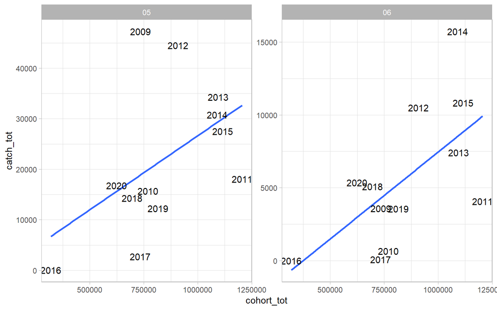

```r
cc_tot |>
  ggplot(aes(cohort_tot, catch_tot)) +
  geom_smooth(method = "lm", se=F) +
  geom_text(aes(label = yr)) +
  facet_wrap(~area_code, scales = "free")
```

However, the A6 linear relationship is weakly significant at 5%.

```r
summary(lm(catch_tot ~ cohort_tot, data = filter(cc_tot, area_code == "05")))
```

```
#>
#> Call:
#> lm(formula = catch_tot ~ cohort_tot, data = filter(cc_tot, area_code ==
#>     "05"))
#>
#> Residuals:
#>    Min     1Q Median     3Q    Max
#> -16071  -7267  -2958   2375  28374
#>
#> Coefficients:
#>               Estimate Std. Error t value Pr(>|t|)
#> (Intercept) -2.652e+03  1.431e+04  -0.185    0.857
#> cohort_tot   2.930e-02  1.633e-02   1.794    0.103
#>
#> Residual standard error: 13730 on 10 degrees of freedom
#> Multiple R-squared:  0.2434, Adjusted R-squared:  0.1678
#> F-statistic: 3.218 on 1 and 10 DF,  p-value: 0.1031
```

```r
summary(lm(catch_tot ~ cohort_tot, data = filter(cc_tot, area_code == "06")))
```

```
#>
#> Call:
#> lm(formula = catch_tot ~ cohort_tot, data = filter(cc_tot, area_code ==
#>     "06"))
#>
#> Residuals:
#>     Min      1Q  Median      3Q     Max
#> -5845.9 -2287.5   -16.1  2110.0  7196.4
#>
#> Coefficients:
#>               Estimate Std. Error t value Pr(>|t|)
#> (Intercept) -4.483e+03  4.083e+03  -1.098   0.2979
#> cohort_tot   1.194e-02  4.658e-03   2.563   0.0282 *
#> ---
#> Signif. codes:  0 '***' 0.001 '**' 0.01 '*' 0.05 '.' 0.1 ' ' 1
#>
#> Residual standard error: 3917 on 10 degrees of freedom
#> Multiple R-squared:  0.3965, Adjusted R-squared:  0.3361
#> F-statistic: 6.569 on 1 and 10 DF,  p-value: 0.02823
```

## 2.2 Excluding 2016 only

Removing 2016 underscores that a simple linear fit is possible but ill-advised.

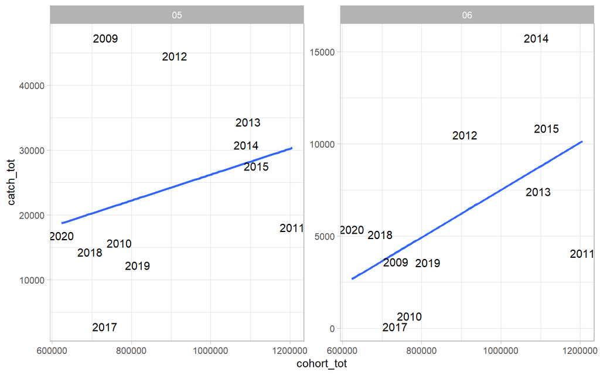

```r
cc_tot |>
  filter(yr != "2016") |>
  ggplot(aes(cohort_tot, catch_tot)) +
  geom_smooth(method = "lm", se=F) +
  geom_text(aes(label = yr)) +
  facet_wrap(~area_code, scales = "free")
```

And removing 2106 also makes the A6 relationship non-significant.

```r
summary(lm(catch_tot ~ cohort_tot, data = filter(cc_tot, area_code == "05", yr != "2016")))
```

```
#>
#> Call:
#> lm(formula = catch_tot ~ cohort_tot, data = filter(cc_tot, area_code ==
#>     "05", yr != "2016"))
#>
#> Residuals:
#>    Min     1Q Median     3Q    Max
#> -18138  -8114  -1920   4494  26322
#>
#> Coefficients:
#>              Estimate Std. Error t value Pr(>|t|)
#> (Intercept) 6.243e+03  2.013e+04   0.310    0.763
#> cohort_tot  1.998e-02  2.211e-02   0.904    0.390
#>
#> Residual standard error: 14150 on 9 degrees of freedom
#> Multiple R-squared:  0.08322,    Adjusted R-squared:  -0.01864
#> F-statistic: 0.817 on 1 and 9 DF,  p-value: 0.3896
```

```r
summary(lm(catch_tot ~ cohort_tot, data = filter(cc_tot, area_code == "06", yr != "2016")))
```

```
#>
#> Call:
#> lm(formula = catch_tot ~ cohort_tot, data = filter(cc_tot, area_code ==
#>     "06", yr != "2016"))
#>
#> Residuals:
#>     Min      1Q  Median      3Q     Max
#> -6077.2 -2722.6  -492.1  2285.9  7072.3
#>
#> Coefficients:
#>               Estimate Std. Error t value Pr(>|t|)
#> (Intercept) -5.364e+03  5.858e+03  -0.916   0.3837
#> cohort_tot   1.286e-02  6.434e-03   1.999   0.0767 .
#> ---
#> Signif. codes:  0 '***' 0.001 '**' 0.01 '*' 0.05 '.' 0.1 ' ' 1
#>
#> Residual standard error: 4118 on 9 degrees of freedom
#> Multiple R-squared:  0.3075, Adjusted R-squared:  0.2305
#> F-statistic: 3.996 on 1 and 9 DF,  p-value: 0.07669
```

## 2.3 Since 2017

Finally, a focus on the most recent years indicates that the preseason cohort does not effectively inform the postseason catch.

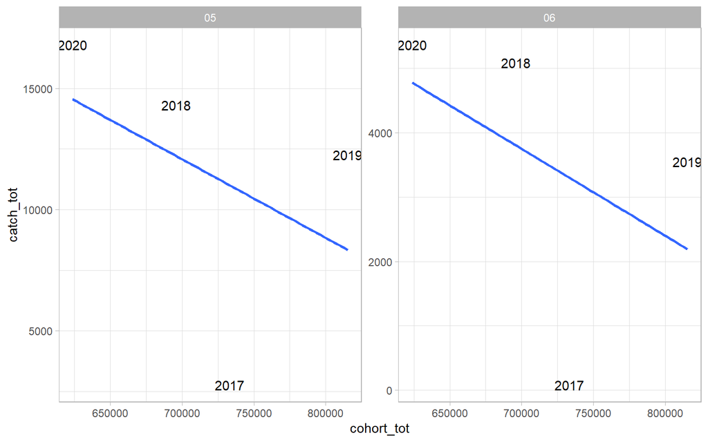

```r
cc_tot |>
  filter(yr %in% as.character(2017:2021)) |>
  ggplot(aes(cohort_tot, catch_tot)) +
  geom_smooth(method = "lm", se=F) +
  geom_text(aes(label = yr)) +
  facet_wrap(~area_code, scales = "free")
```

```r
summary(lm(catch_tot ~ cohort_tot, data = filter(cc_tot, area_code == "05", yr %in% as.character(2017:2021))))
```

```
#>
#> Call:
#> lm(formula = catch_tot ~ cohort_tot, data = filter(cc_tot, area_code ==
#>     "05", yr %in% as.character(2017:2021)))
#>
#> Residuals:
#>     1     2     3     4
#> -8250  2093  3918  2239
#>
#> Coefficients:
#>               Estimate Std. Error t value Pr(>|t|)
#> (Intercept)  3.477e+04  3.553e+04   0.979    0.431
#> cohort_tot  -3.242e-02  4.931e-02  -0.657    0.578
#>
#> Residual standard error: 6812 on 2 degrees of freedom
#> Multiple R-squared:  0.1777, Adjusted R-squared:  -0.2334
#> F-statistic: 0.4322 on 1 and 2 DF,  p-value: 0.5785
```

```r
summary(lm(catch_tot ~ cohort_tot, data = filter(cc_tot, area_code == "06", yr %in% as.character(2017:2021))))
```

```
#>
#> Call:
#> lm(formula = catch_tot ~ cohort_tot, data = filter(cc_tot, area_code ==
#>     "06", yr %in% as.character(2017:2021)))
#>
#> Residuals:
#>       1       2       3       4
#> -3228.7  1285.5  1357.8   585.4
#>
#> Coefficients:
#>               Estimate Std. Error t value Pr(>|t|)
#> (Intercept)  1.320e+04  1.393e+04   0.948    0.443
#> cohort_tot  -1.350e-02  1.933e-02  -0.698    0.557
#>
#> Residual standard error: 2670 on 2 degrees of freedom
#> Multiple R-squared:  0.196,  Adjusted R-squared:  -0.2059
#> F-statistic: 0.4877 on 1 and 2 DF,  p-value: 0.5572
```

# 3 Marked catch ~ marked cohort

Nonetheless, given the prevalence of MSF opportunity, it may be preferable to examine only the marked cohort.

```r
cc_m <- inner_join(
  fs_ps_spt |>
    filter(type == "pst", area_code %in% c("05", "06")) |>
    group_by(type, area_code, yr) |>
    summarise(catch_tot = sum(val), .groups = "drop")
  ,
  cohort_pre_ps |>
    filter(StockID %% 2 < 1) |>
    group_by(yr = RunYear) |>
    summarise(cohort_m = sum(cohort), .groups = "drop")
  ,
  by = "yr"
)
```

Similar to the total cohort, the relationship is highly leveraged by 2016 and effectively absent since 2017.

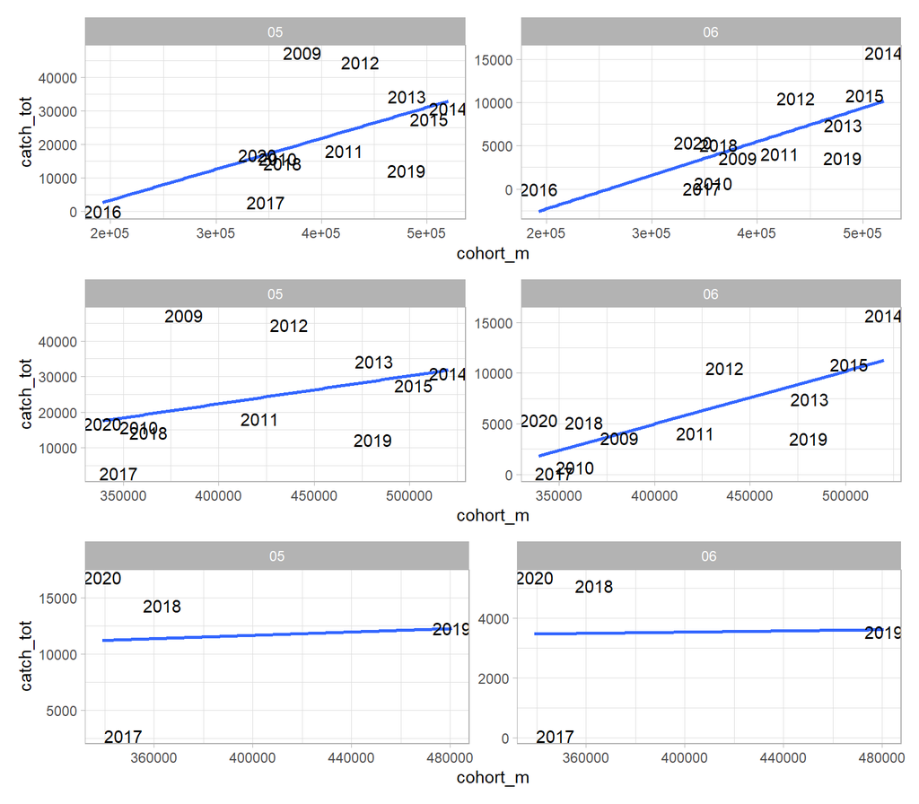

```r
(cc_m |>
  ggplot(aes(cohort_m, catch_tot)) +
  geom_smooth(method = "lm", se=F) +
  geom_text(aes(label = yr)) +
  facet_wrap(~area_code, scales = "free")
)+(
cc_m |>
  filter(yr != "2016") |>
  ggplot(aes(cohort_m, catch_tot)) +
  geom_smooth(method = "lm", se=F) +
  geom_text(aes(label = yr)) +
  facet_wrap(~area_code, scales = "free")
)+(
cc_m |>
  filter(yr %in% as.character(2017:2021)) |>
  ggplot(aes(cohort_m, catch_tot)) +
  geom_smooth(method = "lm", se=F) +
  geom_text(aes(label = yr)) +
  facet_wrap(~area_code, scales = "free")
) + plot_layout(ncol = 1)
```

This remains the case when comparing only marked catch to the marked cohort.

```r
cc_mm <- inner_join(
  fs_ps_spt |>
    filter(type == "pst", area_code %in% c("05", "06"), var == "MSFQuota") |>
    group_by(type, area_code, yr) |>
    summarise(catch_m = sum(val), .groups = "drop")
  ,
  cohort_pre_ps |>
    filter(StockID %% 2 < 1) |>
    group_by(yr = RunYear) |>
    summarise(cohort_m = sum(cohort), .groups = "drop")
  ,
  by = "yr"
)
```

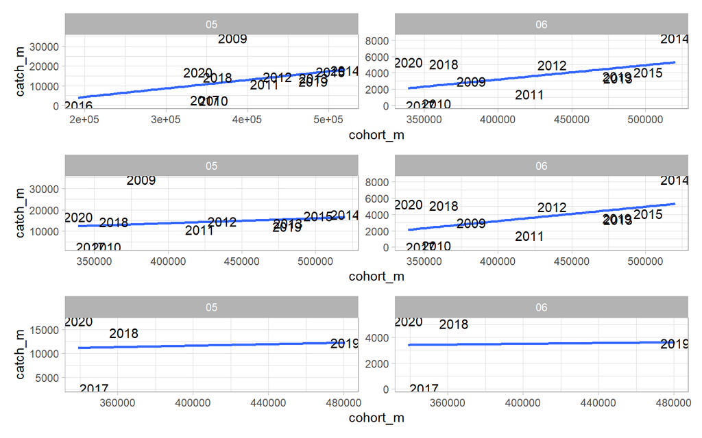

```r
(cc_mm |>
  ggplot(aes(cohort_m, catch_m)) +
  geom_smooth(method = "lm", se=F) +
  geom_text(aes(label = yr)) +
  facet_wrap(~area_code, scales = "free")
)+(
cc_mm |>
  filter(yr != "2016") |>
  ggplot(aes(cohort_m, catch_m)) +
  geom_smooth(method = "lm", se=F) +
  geom_text(aes(label = yr)) +
  facet_wrap(~area_code, scales = "free")
)+(
cc_mm |>
  filter(yr %in% as.character(2017:2021)) |>
  ggplot(aes(cohort_m, catch_m)) +
  geom_smooth(method = "lm", se=F) +
  geom_text(aes(label = yr)) +
  facet_wrap(~area_code, scales = "free")
) + plot_layout(ncol = 1)
```

# 4 Marked September catch only

Limiting to coho FRAM timestep 4, the month of September, yields an inverse relationship for A5 and a non-informative one for A6.

```r
cc_mm_4 <- inner_join(
  fs_ps_spt |>
    filter(type == "pst", area_code %in% c("05", "06"), var == "MSFQuota", ts == 4) |>
    group_by(type, area_code, yr) |>
    summarise(catch_m_4 = sum(val), .groups = "drop")
  ,
  cohort_pre_ps |>
    filter(StockID %% 2 < 1) |>
    group_by(yr = RunYear) |>
    summarise(cohort_m = sum(cohort), .groups = "drop")
  ,
  by = "yr"
)
```

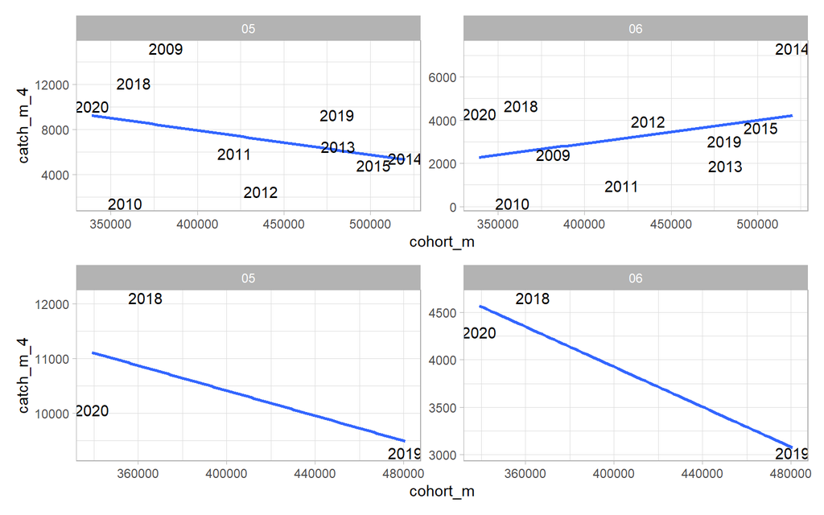

```r
(cc_mm_4 |>
  ggplot(aes(cohort_m, catch_m_4)) +
  geom_smooth(method = "lm", se=F) +
  geom_text(aes(label = yr)) +
  facet_wrap(~area_code, scales = "free")
)+(
cc_mm_4 |>
  filter(yr %in% as.character(2017:2021)) |>
  ggplot(aes(cohort_m, catch_m_4)) +
  geom_smooth(method = "lm", se=F) +
  geom_text(aes(label = yr)) +
  facet_wrap(~area_code, scales = "free")
) + plot_layout(ncol = 1)
```